# A Gentle Introduction on Market Basket Analysis - Association Rules

## Create some rules

- We use the Apriori algorithm in arules library to mine frequent itemsets and association rules. The algorithm employs level-wise search for frequent itemsets.
- We pass supp=0.001 and conf=0.8 to return all the rules have a support of at least 0.1% and confidence of at least 80%.
- We sort the rules by decreasing confidence.
- Have a look the summary of the rules.

```r
rules <- apriori(tr, parameter = list(supp=0.001, conf=0.8))
```

```
Apriori

Parameter specification:
 confidence minval smax arem  aval originalSupport maxtime support minlen maxlen target   ext
        0.8    0.1    1 none FALSE            TRUE       5   0.001      1     10  rules FALSE

Algorithmic control:
 filter tree heap memopt load sort verbose
    0.1 TRUE TRUE  FALSE TRUE    2    TRUE

Absolute minimum support count: 19

set item appearances ...[0 item(s)] done [0.00s].
set transactions ...[27165 item(s), 19297 transaction(s)] done [0.06s].
sorting and recoding items ... [2407 item(s)] done [0.01s].
creating transaction tree ... done [0.01s].
checking subsets of size 1 2 3 4 5 6 7 8 9 10
```

```
Mining stopped (maxlen reached). Only patterns up to a length of 10 returned!
```

```
 done [0.86s].
writing ... [87110 rule(s)] done [0.11s].
creating S4 object  ... done [0.06s].
```

```r
rules <- sort(rules, by='confidence', decreasing = TRUE)
summary(rules)
```

```
set of 87110 rules

rule length distribution (lhs + rhs):sizes
    2     3     4     5     6     7     8     9    10
  105  3133  9732 26228 29873 14020  3218   680   121

   Min. 1st Qu.  Median    Mean 3rd Qu.    Max.
  2.000   5.000   6.000   5.627   6.000  10.000

summary of quality measures:
    support           confidence          lift             count
 Min.   :0.001036   Min.   :0.8000   Min.   :  8.781   Min.   : 20.00
 1st Qu.:0.001088   1st Qu.:0.8333   1st Qu.: 19.305   1st Qu.: 21.00
 Median :0.001192   Median :0.8750   Median : 24.786   Median : 23.00
 Mean   :0.001383   Mean   :0.8834   Mean   : 50.921   Mean   : 26.69
 3rd Qu.:0.001503   3rd Qu.:0.9231   3rd Qu.: 43.662   3rd Qu.: 29.00
 Max.   :0.018086   Max.   :1.0000   Max.   :622.484   Max.   :349.00

mining info:
 data ntransactions support confidence
   tr         19297   0.001        0.8
```

```r
inspect(rules[1:10])
```

```
     lhs                         rhs             support     confidence lift      count
[1]  {WOBBLY CHICKEN}         => {DECORATION}    0.001451003 1          385.94000 28
[2]  {WOBBLY CHICKEN}         => {METAL}         0.001451003 1          385.94000 28
[3]  {DECOUPAGE}              => {GREETING CARD} 0.001191895 1          344.58929 23
[4]  {BILLBOARD FONTS DESIGN} => {WRAP}          0.001502824 1          622.48387 29
[5]  {WOBBLY RABBIT}          => {DECORATION}    0.001761932 1          385.94000 34
[6]  {WOBBLY RABBIT}          => {METAL}         0.001761932 1          385.94000 34
[7]  {BLACK TEA}              => {SUGAR JARS}    0.002331969 1          212.05495 45
[8]  {BLACK TEA}              => {COFFEE}        0.002331969 1           61.06646 45
[9]  {ART LIGHTS}             => {FUNK MONKEY}   0.001969218 1          507.81579 38
[10] {FUNK MONKEY}            => {ART LIGHTS}    0.001969218 1          507.81579 38
```

- 100% customers who bought “WOBBLY CHICKEN” end up bought “DECORATION” as well.
- 100% customers who bought “BLACK TEA” end up bought “SUGAR JAR” as well.

And plot these top 10 rules.

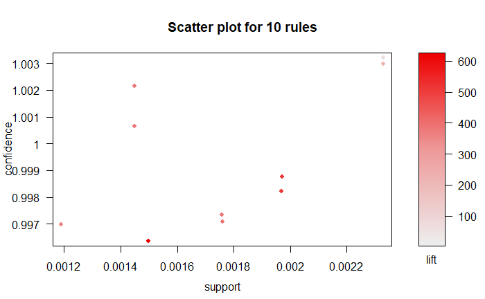

```r
topRules <- rules[1:10]
plot(topRules)
```

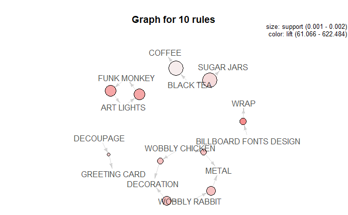

```r
plot(topRules, method="graph")
```

[figure not shown]

```r
plot(topRules, method = "grouped")
```

Reference: [R and Data Mining](http://www.rdatamining.com/examples/association-rules)